# Youtube Trending Videos

Sean Nguyen

May 18, 2018

## Summary

Exploratory data analysis of over 30,000 Youtube videos that were Trending on April 24, 2018 in the US.

## Popular Videos

### Most Viewed Videos Today

| Rank | Video | Channel | Views |
| --- | --- | --- | --- |
| 1 | YouTube Rewind: The Shape of 2017 \| #YouTubeRewind | YouTube Spotlight | 149376127 |
| 2 | YouTube Rewind: The Shape of 2017 \| #YouTubeRewind | YouTube Spotlight | 137843120 |
| 3 | YouTube Rewind: The Shape of 2017 \| #YouTubeRewind | YouTube Spotlight | 125432237 |
| 4 | YouTube Rewind: The Shape of 2017 \| #YouTubeRewind | YouTube Spotlight | 113874632 |
| 5 | Luis Fonsi, Demi Lovato - Échame La Culpa | LuisFonsiVEVO | 102012605 |
| 6 | YouTube Rewind: The Shape of 2017 \| #YouTubeRewind | YouTube Spotlight | 100911567 |
| 7 | Marvel Studios’ Avengers: Infinity War Official Trailer | Marvel Entertainment | 91933007 |
| 8 | Luis Fonsi, Demi Lovato - Échame La Culpa | LuisFonsiVEVO | 91552137 |
| 9 | Marvel Studios’ Avengers: Infinity War Official Trailer | Marvel Entertainment | 89930713 |
| 10 | Marvel Studios’ Avengers: Infinity War Official Trailer | Marvel Entertainment | 87449453 |

### Views vs Likes/Dislikes

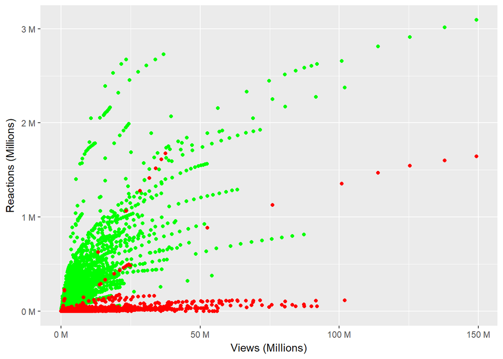

Likes (green) and dislikes (red) both increase logarithmically with views, suggesting that earlier viewers are more likely to react (e.g. subscribers), while later viewers are less interested (maybe the video is on the Trending page at this point). The data points follow several distinct curves, which suggests that certain types of videos get more likes per view than others.

## Popular Channels

### Channels With Most Trending Videos

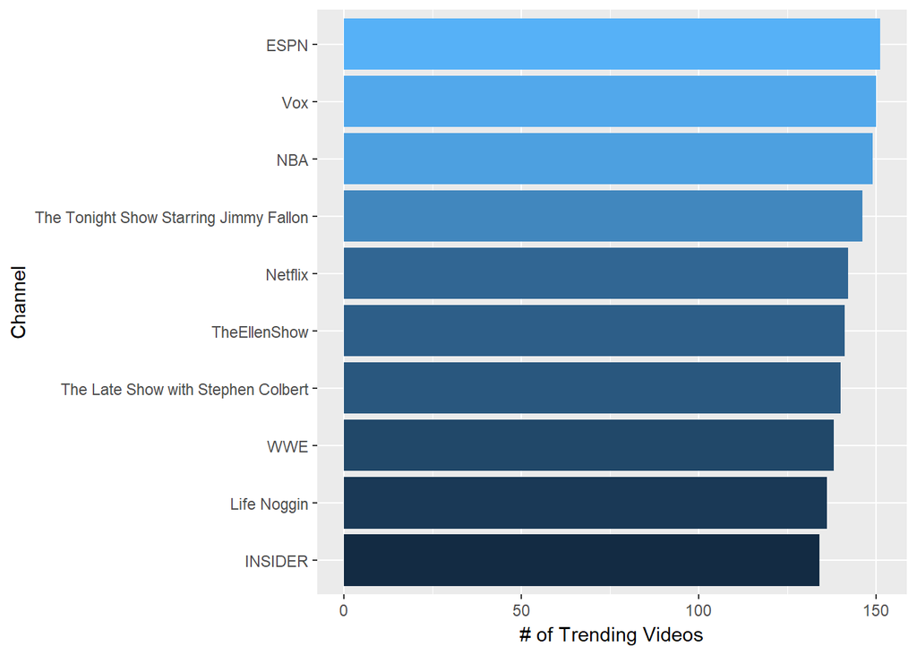

Most of the top 10 channels are sports channels or talk shows. Channels like ESPN have a broad appeal and often post lots of short clips each day.

### Average Views Per Video

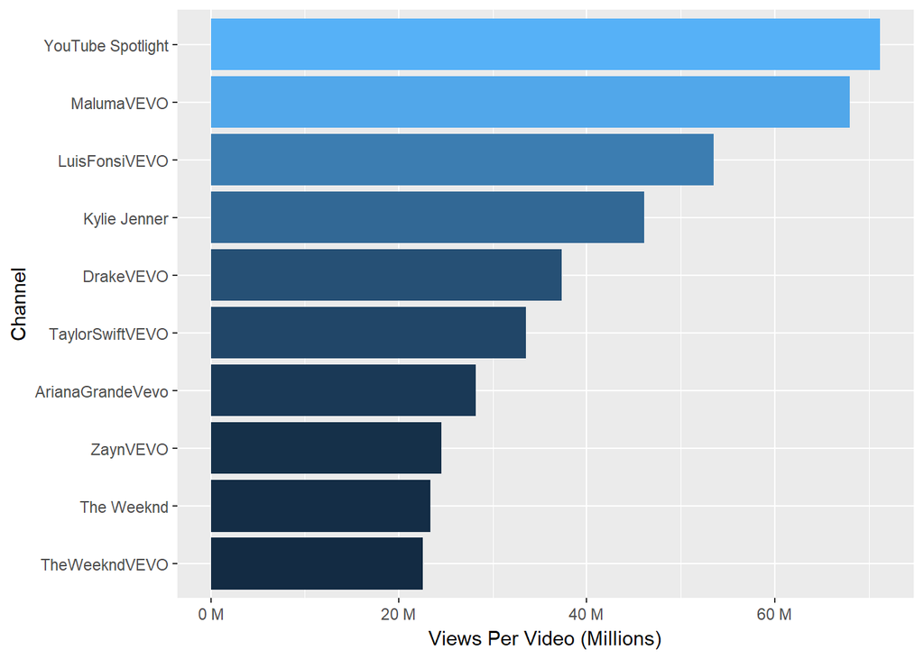

Mostly mainstream music, except for Kylie Jenner and YouTube Spotlight.

## Trending Over Time

Most videos start trending after about a week, but it can sometimes take years:

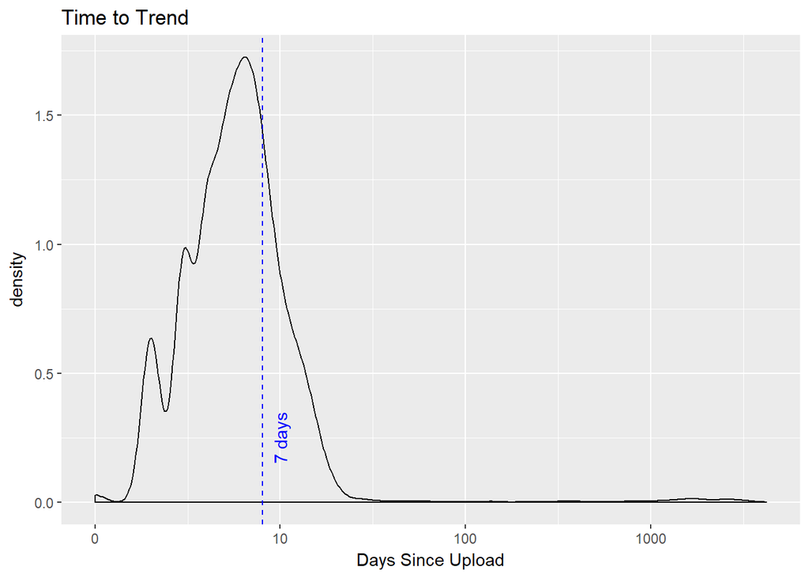

Some videos even trend the same day:

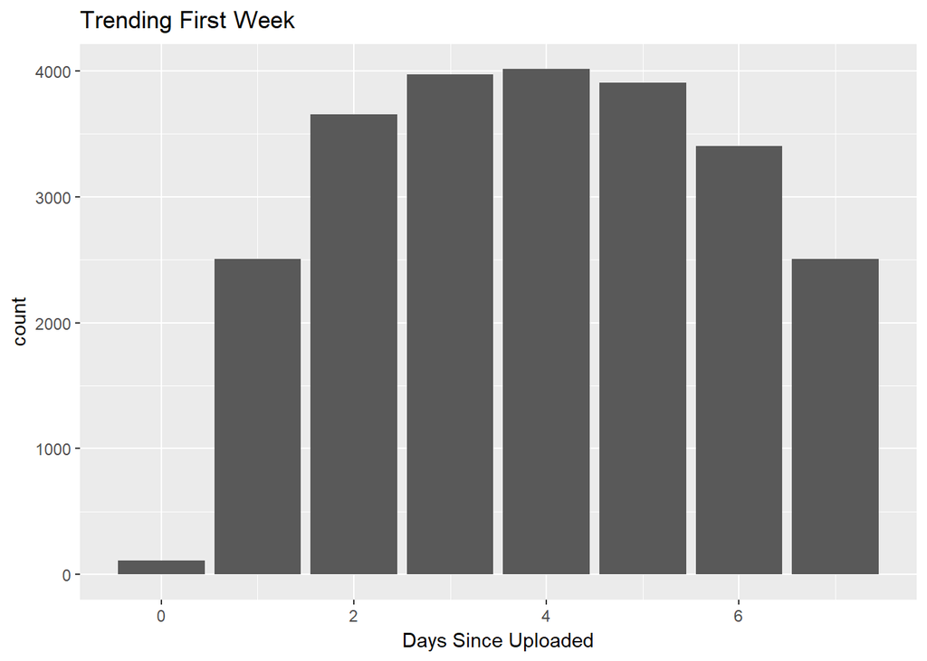

Today’s Trending videos have been trending for anywhere from 0 to 5 months:

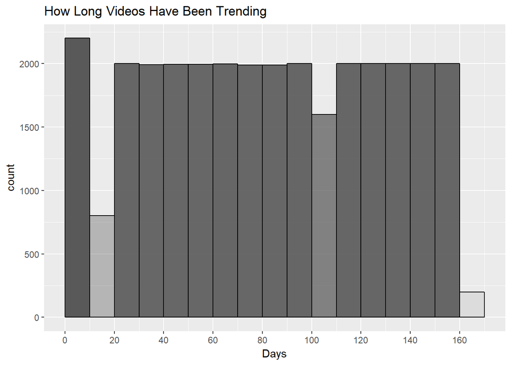

Some videos uploaded in the early 2000s are still trending today, but the vast majority of today’s trending videos were uploaded within the past 12 months:

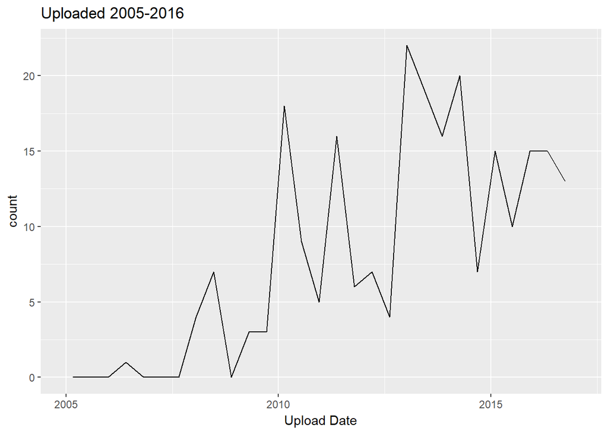

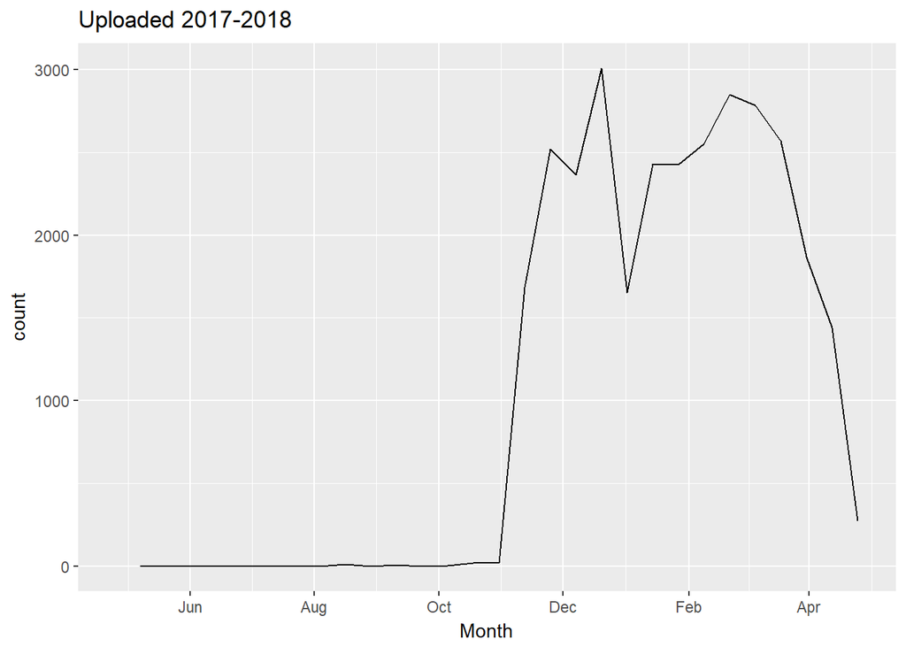

## Common Words

### Titles

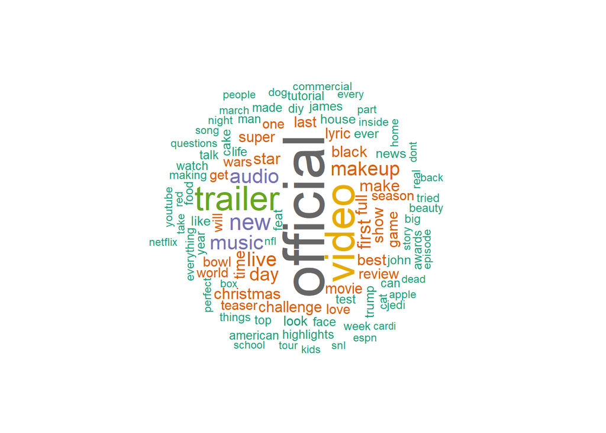

### Tags

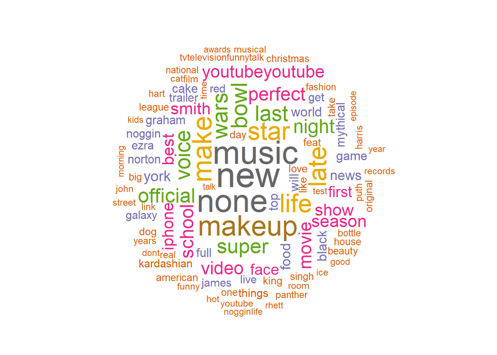